# Hierarchical Clustering Analysis: SB LTER Stream Chemistry

Sachiko Lamen

2/15/2022

```r
knitr::opts_chunk$set(echo = TRUE, message = FALSE, warning = FALSE)

library(tidyverse)
library(here)
library(NbClust)
library(cluster)
library(factoextra)
library(dendextend)
library(ggdendro)
```

### **Overview**

#### **Citation**

Santa Barbara Coastal LTER and J. Melack. 2019. SBC LTER: Land: Stream chemistry in the Santa Barbara Coastal drainage area, ongoing since 2000 ver 16. Environmental Data Initiative. https://doi.org/10.6073/pasta/67a558a24ceed9a0a5bf5e46ab841174.

```r
# Read in data
streams <- read_csv(here("data", "sbc_lter_registered_stream_chemistry.csv"))

# Convert -999 values to NA
streams_clean <- streams %>%
  mutate(across(c(1:12), na_if, -999))
```

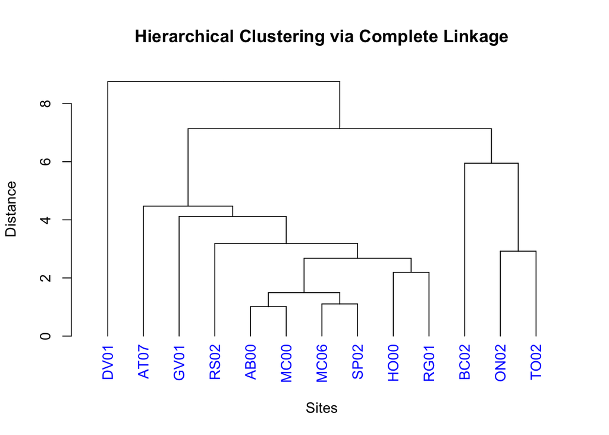

```r
# Calculate distance matrix
stream_euc_distance <- dist(streams_scaled, method = 'euclidian')

# Hierarchical clustering using complete method
stream_hc_complete <- hclust(stream_euc_distance, method = 'complete')

### convert to class dendrogram
dend_complete <- as.dendrogram(stream_hc_complete)

# Plot dendrogram
dend_complete %>%
  set("labels_col", "blue") %>%
  plot(main = "Hierarchical Clustering via Complete Linkage",
       xlab = "Sites", ylab = "Distance")
```

**Figure 1.** Complete linkage dendrogram depicting multivariate clustering for water chemistry by site. Intersection of lines represent links between groups. The distance of the lines is proportional to the Euclidean distance between clusters.

### **Conclusions**

It appears that there are 3-4 distinct clusters. Of these we see that:

- - Site DV01 diverges early on, likely due to the large difference in ammonium and phosphorous concentration (micro moles/L) compared to all other sites.
- - The cluster encapsulating BC02, ON02, and TO02 was likely formed due to similarities in nitrate (micro moles/L) and total particulate nitrogen (micro moles/L) concentrations.
- - The above mentioned group could be sliced into two clusters (making 4 instead of 3 clusters) as ON02 and TO02 are more similar in their particulate nitrogen and nitrate concentrations
- - 9/13 sites are all in the same cluster

From the above information it is apparent that further investigation into the relationships between these variables is necessary, perhaps through a principal components analysis. Additionally, the largest cluster should be looked examined at greater resoultion to better understand the nuances in variable relationships between these sites.